# Investigate the Stroop Effect

A Project for Inferential Statistics

## Abstract

This project paper has been prepared under Udacity’s Inferential Statistics course. The project calls for investigating the [Stroop Effect](https://en.wikipedia.org/wiki/Stroop_effect) by statistically examining results from a sample of participants.

A hypothesis regarding the outcome of the task will be proposed and tested against the data set.

## Variables

The dependent variable is the time taken to complete each test, while the independent variable is the words condition (congruent or incongruent).

## Hypotheses

The null hypothesis is that the time taken to complete the congruent test is the same as that taken for the incongruent test.

The alternative hypothesis proposes that the time taken to complete the two tests are different.

The hypotheses can be symbolized as follows:

$H_0: \mu_{inc} = \mu_{con}$

$H_A: \mu_{inc} \neq \mu_{con}$

where,

$\mu_{inc}$ is the sample mean for Inconguent words condition task,  
$\mu_{con}$ is the sample mean for Congruent words condition task.

The statistical test will be a dependent t-test for paired samples since the samples are drawn from the same population.

I will use 2-tailed t-critical values in order to fit the alternative hypothesis which is non-directional (i.e. $\mu_{inc}$ could either increase or decrease in relation to $\mu_{con}$).

The significance level, i.e. alpha is set at 0.05.

I will also examine the sample’s *Cohen’s d* to evaluate the effect size.

#### My Experience with Stroop Task

The Stroop task testing comprises calling out the name of colour used to mark each word, and timing the duration taken to complete naming the colours for a fixed quantity of words.

The test starts with congruent words condition before finishing with the incongruent words condition.

I took longer to complete the task with incongruent words condition. Did other participants experience the same?

## Descriptive Statistics

```
## 'data.frame':    24 obs. of  2 variables:
##  $ Congruent  : num  12.08 16.79 9.56 8.63 14.67 ...
##  $ Incongruent: num  19.3 18.7 21.2 15.7 22.8 ...
```

The dataset contains time entries for 24 participants, i.e. sample size is 24.

#### Central Tendency

```
##    Congruent      Incongruent
##  Min.   : 8.63   Min.   :15.69
##  1st Qu.:11.90   1st Qu.:18.72
##  Median :14.36   Median :21.02
##  Mean   :14.05   Mean   :22.02
##  3rd Qu.:16.20   3rd Qu.:24.05
##  Max.   :22.33   Max.   :35.26
```

So, it appears other participants in the sample had the same experience - the measures of central tendency (median and mean) for Incongruent are higher than the Congruent values. On average, the Incongruent task took almost 8 seconds longer to complete than its counterpart.

#### Variability

```
##   IQR_cgrt IQR_incgrt var_cgrt var_incgrt stdev_cgrt stdev_incgrt
## 1   4.3055    5.33475 12.66903   23.01176   3.559358     4.797057
```

| Abbr. | Meaning |
| --- | --- |
| IQR | Inter-quartile Range |
| var | Variance |
| stdev | Standard Deviation |
| cgrt | Congruent words condition |
| incgrt | Incongruent words condition |

Incongruent words condition task in the sample results has a larger spread (variability) - all three measures of variability in the sample indicate longer duration (seconds) compared to Congruent task.

## Visualizations

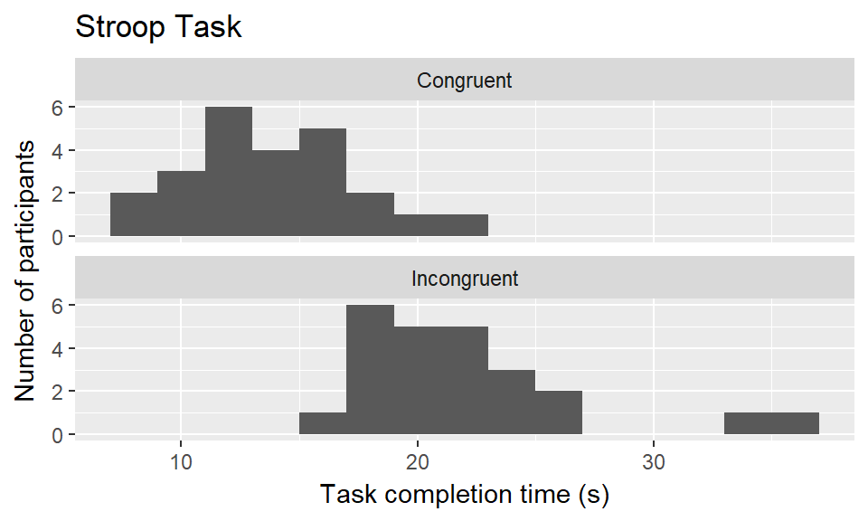

The histogram plot for Congruent task approximates to a normal distribution. On the other hand, the Incongruent task histogram suggests a positively skewed distribution.

The normal distribution for Congruent task seems to represent a collection of the candidates that have a spread of reaction time and literacy prowess. Both these capabilities can be improved with practice to reduce the task completion time. I expect this to be the distribution too if an entire literate population took the test on Congruent words condition.

However, the skewed distribution observed in the Incongruent task suggests that this test is an “equalizer” in the sense that even the more quick to read and react could not reduce the completion time beyond a floor value (~ 18 seconds).

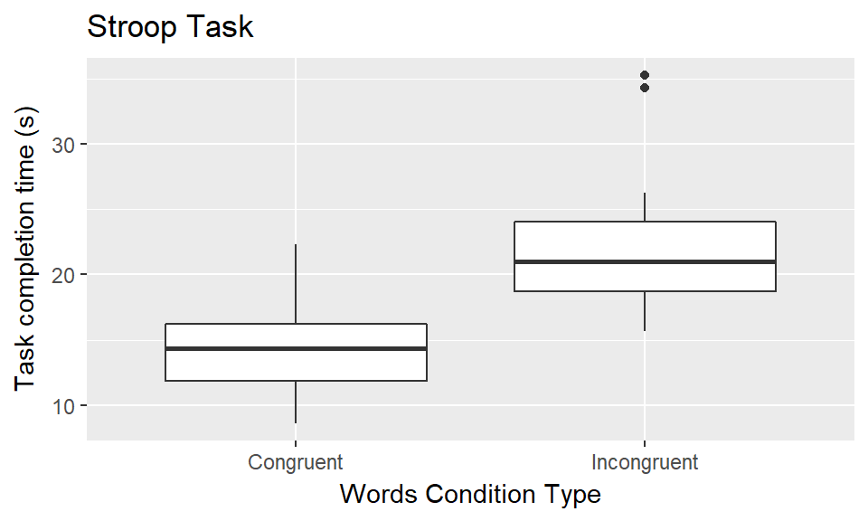

The plots illustrate a clear difference in completion time between the tasks with differing words condition - Incongruent words condition tasks take a longer time to complete compared to tasks with Congruent words condition.

An interesting observation is that the Congruent boxplot’s median line lies in the upper half of the “box” in the dataset suggesting that notable handful of individuals (i.e. 25% of samples) in the dataset that could complete the task faster. Contrast this with the median line of the Incongruent boxplot which lies in the middle of the “box” - suggesting that the previously quick individuals could not do notably better in completing the Incongruent task as they did in the Congruent task.

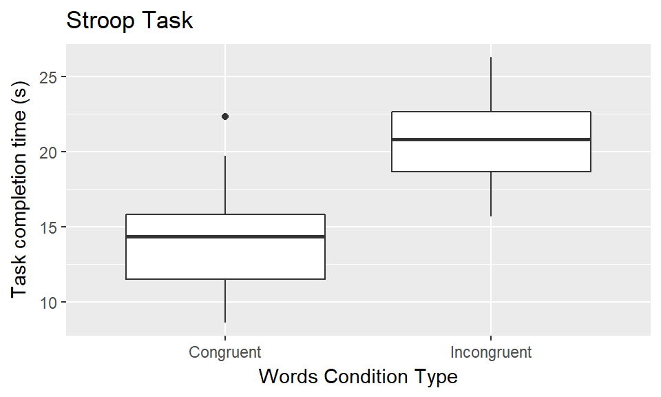

By filtering away the slowest participants from the dataset (i.e. completion time exceeding 30 seconds), we can see a more striking difference in the performance of “quick” individuals between the two tasks.

So, how did each individual do between the 2 tasks?

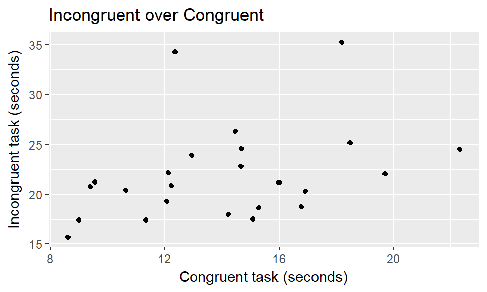

There is a correlation between the time taken for the Congruent and Incongruent tasks.

Surprisingly, the individuals who took the longer time (> 30s) to finish the Incongruent task were not the slower indivdiuals in the Congruent task.

Let’s filter these individuals out, and re-plot with a fitted line.

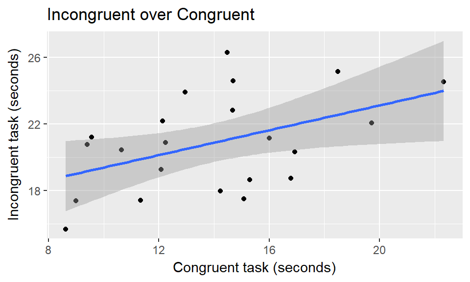

```
## [1] 0.4654006
```

## Statistical Testing

Recall that the hypotheses are as follows:

$H_0: \mu_{inc} = \mu_{con}$

$H_A: \mu_{inc} \neq \mu_{con}$

To establish if we should reject the null or if we fail to reject the null, we take the following steps:

##### 1. Establish the sample size

```
## [1] 24
```

$n = 24$

##### 2. Establish the mean difference

$\mu_d = \mu_{inc} - \mu_{con}$

```
## [1] 7.964792
```

$\mu_d = 7.96$

##### 3. Establish standard deviation of difference

$S_d = \sqrt{\frac{\sum{(d_i - \mu_d)^2}}{n-1}}$  
$\text{ ,where } d_i \text{ is the difference for pair } i$

```
## [1] 4.864827
```

$S_d = 4.86$

##### 4. Establish the standard error of mean (SE)

$\text{SE} = \frac{S_d}{\sqrt{n}}$

```
## [1] 0.9930286
```

$\text{SE} = 0.99$

##### 5. Establish the t-statistics

t-statistics = $\frac{\mu_d}{\text{SE}}$

```
## [1] 8.020707
```

t-statistics = 8.02

##### 6. Degree of freedom based on dependent t-test of paired samples

d.f. = n - 1 = 23

##### 7. Establish the 2-tailed t-critical value based on alpha of 0.05

```
## [1] 2.068658
```

t-critical(23) = $\pm2.069, p<.025$

##### 8. Test results

We can see that t-statistics (8.02) lies beyond the t-critical value (+/- 2.069). Thus, we can reject the null hypothesis.

#### 95% Confidence Intervals of Mean Difference between the 2 Words Conditions

Establishing the Margin of Error using 2-tailed t-test with alpha of 0.05.

Margin of Error = t<sub>critical</sub> x SE

```
## [1] 2.054236
```

Margin of Error = 2.05

Hence, the 95% confidence intervals for the difference in time (seconds) taken to complete the Congruent and Incongruent words condition tasks are:

```
## [1] 5.910555
```

```
## [1] 10.01903
```

95% CI [5.91, 10.02].

## Effect Size

*Cohen’s d* is derived by the following formula:

$\text{Cohen's d} = \frac{\mu_i - \mu_c}{S_d} = \frac{\mu_d}{S_d}$

```
## [1] 1.63722
```

$\text{Cohen's d} = 1.64$

The distance between means is more than 0.8 standardized unit away from one another which represents a large effect size.

## Conclusion

Based on t-test result, we can reject the null hypothesis to accept that the alternate hypothesis has statistical significance.

*Cohen’s d* value indicates that there is meaningful effect size in the mean difference.

The result matches with observations made through the histograms and boxplots illustrating the difference in time taken for the 2 task types.

#### Further Thoughts

The Stroop effect is theorized to be the manifestation of a race condition in the brain where both relevant (i.e. actual colour used on the word) and irrelevant (i.e. the word with name of colour) information are processed in parallel, but race to enter the processing centre of the brain when a response (i.e. when verbalizing the colour’s name) made.

Multi-tasking could result in similar effect. For instance, individuals attempting to drive a vehicle while engaging in a conversation on a cellular phone might actually be responding slower to inputs from either task, thus compromising on road safety and simultaneously coming across as inattentive or uninterested to the caller on the other line.